# OktoberfestR

Daloha Rodríguez-Molina

9/27/2017

This is a quick analysis of publicly available Oktoberfest data following [@gresch's](https://github.com/gresch) [blog post](https://gresch.github.io/2017/09/14/201701oktoberfest1985-2016/), and a Shiny app to go along.

# Setup and data overview

This analysis containst publicly available Oktoberfest data 1985-2016. The data is available at the [Munich Opendata portal](https://www.opengov-muenchen.de/dataset/oktoberfest/resource/e0f664cf-6dd9-4743-bd2b-81a8b18bd1d2).  
**Disclaimer**: Most of this code was taken from [@gresch's](https://github.com/gresch) [blog post](https://gresch.github.io/2017/09/14/201701oktoberfest1985-2016/). Only the Shiny app was created anew.

### Load the tidyverse and other libraries

```r
library(tidyverse)
library(knitr)
library(scales)
library(ggthemes)
library(dplyr)
```

### Constants

```r
data_file <- 'https://www.opengov-muenchen.de/dataset/8d6c8251-7956-4f92-8c96-f79106aab828/resource/e0f664cf-6dd9-4743-bd2b-81a8b18bd1d2/download/oktoberfestgesamt19852016.csv'
r_90_d <- theme(axis.text.x = element_text(angle = 90, hjust = 1))
caption <- "https://gresch.github.io/"
my_theme <- theme_hc()
cp <- c("#1d3a7b", "#b53fa8", "#224dce", "#529480", "#23f2c0") # color palette "Song of the Unexpected Color Palette" http://www.color-hex.com/color-palette/29752
```

### Read data

```r
data <- read_csv(data_file)
# translate variable names to English
data <- rename(data, year = jahr,
               duration_days = dauer,
               visitor_year = besucher_gesamt,
               visitor_day = besucher_tag,
               beer_price = bier_preis,
               beer_sold = bier_konsum,
               chicken_price = hendl_preis,
               chicken_sold = hendl_konsum)
# unify measures
data$visitor_year <- data$visitor_year * 1000000
data$visitor_day <- data$visitor_day * 1000
data$beer_sold <- data$beer_sold * 100
```

### Create table overview

```r
head(data)
```

| year | duration_days | visitor_year | visitor_day | beer_price | beer_sold | chicken_price | chicken_sold |
| --- | --- | --- | --- | --- | --- | --- | --- |
| 1985 | 16 | 7100000 | 444000 | 3.20 | 5454100 | 4.77 | 629520 |
| 1986 | 16 | 6700000 | 419000 | 3.30 | 5380700 | 3.92 | 698137 |
| 1987 | 16 | 6500000 | 406000 | 3.37 | 5184200 | 3.98 | 732859 |
| 1988 | 16 | 5700000 | 356000 | 3.45 | 5095100 | 4.19 | 720139 |
| 1989 | 16 | 6200000 | 388000 | 3.60 | 5124100 | 4.22 | 775674 |
| 1990 | 16 | 6700000 | 419000 | 3.77 | 5430000 | 4.47 | 750947 |

```r
kable(summary(data))
```

|  | year | duration_days | visitor_year | visitor_day | beer_price | beer_sold | chicken_price | chicken_sold |
| --- | --- | --- | --- | --- | --- | --- | --- | --- |
|  | Min. :1985 | Min. :16.00 | Min. :5500000 | Min. :329000 | Min. : 3.200 | Min. :4869800 | Min. : 3.920 | Min. :351705 |
|  | 1st Qu.:1993 | 1st Qu.:16.00 | 1st Qu.:5975000 | 1st Qu.:369000 | 1st Qu.: 4.638 | 1st Qu.:5249350 | 1st Qu.: 5.215 | 1st Qu.:487974 |
|  | Median :2000 | Median :16.00 | Median :6400000 | Median :394000 | Median : 6.410 | Median :5883400 | Median : 7.975 | Median :559200 |
|  | Mean :2000 | Mean :16.25 | Mean :6318750 | Mean :389188 | Mean : 6.456 | Mean :6071172 | Mean : 7.203 | Mean :583718 |
|  | 3rd Qu.:2008 | 3rd Qu.:16.00 | 3rd Qu.:6525000 | 3rd Qu.:406000 | 3rd Qu.: 8.320 | 3rd Qu.:6698125 | 3rd Qu.: 9.090 | 3rd Qu.:698493 |
|  | Max. :2016 | Max. :18.00 | Max. :7100000 | Max. :444000 | Max. :10.570 | Max. :7922500 | Max. :11.100 | Max. :807710 |

Each year is an observation. There are 32 observations and eight variables:

- The **year** of the Oktoberfest
- The duration of the fest in days (**duration_days**)
- Visitors for each year (**visitor_year**)
- Mean visitors per day for each year (**visitor_day**)
- Mean price for one beer (1 Liter) for each year (**beer_price**)
- Whole amount of beer sold for each year in Liter (**beer_sold**)
- Mean price for one chicken for each year (**chicken_price**)
- Whole amount of chickens sold for each year (**chicken_sold**)

# Data exploration and analysis

### Visitors per year

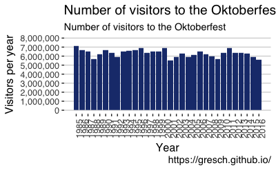

```r
ggplot(data) +
  geom_bar(aes(year, visitor_year),
           stat = "identity",
           fill = cp[1]) +
  labs(
    title = "Number of visitors to the Oktoberfest vary and are currently in decline since 2011",
    subtitle = "Number of visitors to the Oktoberfest",
    caption = caption,
    x = "Year",
    y = "Visitors per year"
    ) +
  scale_y_continuous(
    labels = scales::comma,
    limits = c(0, 8000000),
    breaks = seq(0, 8000000, by = 1000000)) +
  scale_x_continuous(breaks = seq(1985, 2016, by = 1)) +
  r_90_d + my_theme
```

### Show divergence of visitors per year from the mean

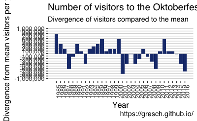

```r
ggplot(data) +
  geom_bar(aes(year, visitor_year - mean(visitor_year)),
           stat = "identity",
           fill = cp[1]) +
  labs(
    title = "Number of visitors to the Oktoberfest vary and are currently in decline since 2011",
    subtitle = "Divergence of visitors compared to the mean ",
    caption = caption,
    x = "Year",
    y = "Divergence from mean visitors per year"
  ) +
  scale_y_continuous(
    labels = scales::comma,
    limits = c(-1000000, 1000000),
    breaks = seq(-1000000, 1000000, by = 100000)
    ) +
  scale_x_continuous(
    breaks = seq(1985, 2016, by = 1)) +
  r_90_d + my_theme
```

> In this graph it is even better to see that in 1985 the most people visited the Oktoberfest. Then there is a stark decline of visitors with 1988 hitting the bottom with ~600,000 visitors less than average. After that the number of visitors increased until 2001 or *nine-eleven*.

# Beer price development

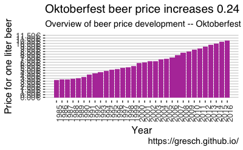

```r
ggplot(data) +
  geom_bar(aes(year, beer_price),
           stat = "identity",
           fill = cp[2]) +
  labs(
    title = "Oktoberfest beer price increases 0.24 € per year, on average",
    subtitle = "Overview of beer price development -- Oktoberfest",
    caption = caption,
    x = "Year",
    y = "Price for one liter beer"
  ) +
  scale_y_continuous(
    labels = scales::dollar_format(suffix = "€", prefix = ""),
    limits = c(0, 11.5),
    breaks = seq(0, 11.5, by = 0.5)) +
  scale_x_continuous(
    breaks = seq(1985, 2016, by = 1)) +
  r_90_d + my_theme
```

### Show beer price increase based on former year

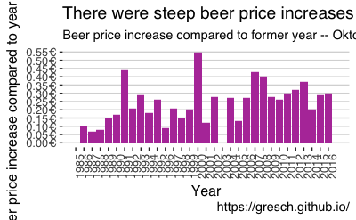

```r
data %>%
  mutate(increase = beer_price - lag(beer_price, default = NA)) %>%
  ggplot() +
  geom_bar(aes(year, increase),
           stat = "identity",
           fill = cp[2]) +
  labs(
    title = "There were steep beer price increases in 1991, 2000, 2007, and 2008 compared to the former years",
    subtitle = "Beer price increase compared to former year -- Oktoberfest",
    caption = caption,
    x = "Year",
    y = "Beer price increase compared to year before"
  ) +
  scale_y_continuous(
    labels = scales::dollar_format(suffix = "€", prefix = ""),
    breaks = seq(-10, +10, by = 0.05)) +
  scale_x_continuous(
    breaks = seq(1985, 2016, by = 1),
    limits = c(1985, 2017)) +
  r_90_d + my_theme
```

> Interestingly, in 1991 there was, on average, a major increase of 0.44€ per beer compared to 1990. Why would that be? The following years the increase levels off until 1996 to rise again with the year 2000 showing a major increase of 0.55€ compared to 1999, which is more than double than the average increase over time.

### Beer sold over the years

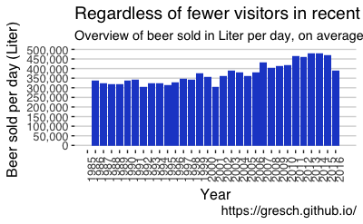

```r
ggplot(data) +
  geom_bar(aes(year, beer_sold / duration_days),
           stat = "identity",
           fill = cp[3]) +
  labs(
    title = "Regardless of fewer visitors in recent years, the amount of sold beer is higher than in the nineties",
    subtitle = "Overview of beer sold in Liter per day, on average -- Oktoberfest",
    caption = caption,
    x = "Year",
    y = "Beer sold per day (Liter)"
  ) +
  scale_y_continuous(
    labels = scales::comma,
    breaks = seq(0, 500000, by = 50000)) +
  scale_x_continuous(
    breaks = seq(1985, 2016, by = 1),
    limits = c(1985, 2017)) +
  r_90_d + my_theme
```

> On average, each year on each day 372,837 liters of beer was sold. The bar chart looks multimodel with a peak in 1999 and a low in 2001 (where less people visited the Oktoberfest). Since then, the amount of beer sold is increasing.

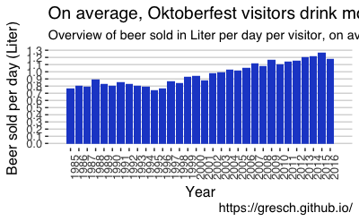

```r
ggplot(data) +
  geom_bar(aes(year, beer_sold / duration_days / visitor_day),
           stat = "identity",
           fill = cp[3]) +
  labs(
    title = "On average, Oktoberfest visitors drink more beer -- over 1.2 Liter in 2015",
    subtitle = "Overview of beer sold in Liter per day per visitor, on average",
    caption = caption,
    x = "Year",
    y = "Beer sold per day (Liter)"
  ) +
  scale_y_continuous(
    labels = scales::comma,
    breaks = seq(0, 1.5, by = 0.1)) +
  scale_x_continuous(
    breaks = seq(1985, 2016, by = 1),
    limits = c(1984, 2017)) +
  r_90_d + my_theme
```

# Chicken price development

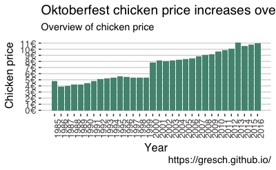

```r
ggplot(data) +
  geom_bar(aes(year, chicken_price),
           stat = "identity",
           fill = cp[4]) +
  labs(
    title = "Oktoberfest chicken price increases over the years with a steep increase in 2000",
    subtitle = "Overview of chicken price",
    caption = caption,
    x = "Year",
    y = "Chicken price"
  ) +
  scale_y_continuous(
    labels = scales::dollar_format(suffix = "€", prefix = ""),
    limits = c(0, 11.5),
    breaks = seq(0, 11.5, by = 1)) +
  scale_x_continuous(
    breaks = seq(1985, 2016, by = 1)) +
  r_90_d + my_theme
```

> The chicken price increased over the years until 1995 to fall slightly. However a huge increase was in the year 2000. The price was increased by 2.47€ more than twelve times the average price increase. Starting in 1985 with 4.77€ and hitting 11.00€ in 2016. That would be an average yearly increase of

$(11.00−4.77)/31=0.2009677$

### Show chicken price increase based on former year

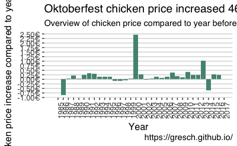

```r
data %>%
  mutate(increase = chicken_price - lag(chicken_price, default = NA)) %>%
  ggplot() +
  geom_bar(aes(year, increase),
           stat = "identity",
           fill = cp[4]) +
  labs(
    title = "Oktoberfest chicken price increased 46% in the year 2000",
    subtitle = "Overview of chicken price compared to year before",
    caption = caption,
    x = "Year",
    y = "Chicken price increase compared to year before"
  ) +
  scale_y_continuous(
    labels = scales::dollar_format(suffix = "€", prefix = ""),
    breaks = seq(-10, +10, by = 0.25)) +
  scale_x_continuous(
    breaks = seq(1985, 2017, by = 1),
    limits = c(1984, 2017)) +
  r_90_d + my_theme
```

> Interestingly, in 1986 the price for chicken dropped four times the average with then a steady increase until 1986. Then in the year 2000 the aforementioned rise of 2.47€. Also, in 2013 we saw a major price increase compared to 2012, namely 1.03€.

# Conlusions

> This was an analysis of available data of the Oktoberfest by Munich Opendata portal. In brief I learned that
> - the total numbers of visitors are in decline
> - in the years were terrorism attacks happened the visitors dropped, esp. in 2001
> - the price for one Liter of beer increases, esp. in the year 2000 with an increase of 0.55€
> - the total amount of beer sold increases
> - alarmingly, the amount of beer per visitor also increases after 1997; on average on visitor drinks over 1.2 liters of beer per day
> - the price for chicken doubled compared to 1999
> - that there was a 46% price increase for a chicken in the year 2000!

> Of course this analysis is limited by the amount of data available for such analyses. Averaging over already aggregated data allow limited insights and statistics need to be interpreted carefully.

If you have any feedback on the analysis, the approach or tools, please feel free to contact [@gresch](https://github.com/gresch)